# Rational Best Approximation of the Matrix Exponential arising in Time-Domain EM Modelling

Implications for the Inverse Problem

Ralph-Uwe Börner

Institute of Geophysics and Geoinformatics | Freiberg | Germany

## Motivation

### TEM Forward Modelling

- Euler Time-stepping methods: Slow, no parallelization
- Krylov subspace methods: Optimal performance
- Rational Best Approximation (RBA): Easy to parallelize

### TEM Inversion

- Relies on fast and efficient forward and adjoint solvers
  - Time-stepping: Slow
  - Krylov subspace methods: Gradient calculation
  - RBA: Gradient trivial

## Forward problem

Initial value problem: Find $\mathbf{E}(\mathbf{r}, t) \in \Omega \subset \mathbb{R}^{3}$ and $t > 0$ subject to
$$\begin{align}
\color{red}{\nabla \times \mu^{-1} \nabla \times }\color{lightgreen}\mathbf{E} + \color{blue}\sigma \,\color{black}\partial_{t} \color{lightgreen}\mathbf{E} & = \mathbf{0} \\
\color{magenta}\mathbf{E}(0) & = \color{magenta}\mathbf{q}(\mathbf{r}) \color{black} + \text{B.C.}
\end{align}$$

Discretization: Find $\mathbf{u}(t) \in \mathbb{R}^M$ for given $\mathbf{m} \in \mathbb{R}^P$
$$\begin{align}
\color{red}\mathbf{K}\color{lightgreen}\mathbf{u}\color{black} + \color{blue}\mathbf{M}(\mathbf{m})\color{black}\partial_{t}\color{lightgreen}\mathbf{u} & = \mathbf{0} \\
\color{magenta}\mathbf{u}(0) & = \color{magenta}\mathbf{b} = \mathbf{M}^{-1} \mathbf{f}
\end{align}$$
Initial value:
$$\color{magenta}\mathbf{u}_{0} = \color{magenta}\mathbf{b} = \mathbf{M}^{-1} \mathbf{f}$$

## Inversion of time-domain data

Find $\mathbf{m}$ such that
$$\Phi(\mathbf{m}) = \Phi_d(\mathbf{m}) + \lambda \Phi_m(\mathbf{m}) \to \text{min!}$$
where
$$\Phi_d(\mathbf{m}) = \frac{1}{2} \bigg\| \mathbf{Q}\mathbf{u} - \mathbf{d}\bigg\|_2^2$$
is the *data misfit functional* with predicted data $\mathbf{Q}\mathbf{u}$, and observed data $\mathbf{d}$.
$$\Phi_m(\mathbf{m}) = \frac{\lambda}{2} \bigg\| \mathbf{C}(\mathbf{m} - \mathbf{m}_\text{ref})\bigg\|_2^2$$
is the regularization functional with regularization parameter $\lambda$.

## Gradient

Necessary condition for minimum of $\Phi(\mathbf{m})$:
$$\begin{aligned}
\nabla_{\mathbf{m}} \Phi (\mathbf{m}) & = \mathbf{0} \\
& = \mathbf{J}^{\top}(\mathbf{Q}{\color{red}\mathbf{u}} - \mathbf{d}) + \lambda \nabla_{\mathbf{m}} \Phi_m(\mathbf{m})
\end{aligned}$$
Jacobian $\mathbf{J}(\mathbf{m})$:
$$\mathbf{J}(\mathbf{m}) = \mathbf{Q}\color{red}\nabla_{\mathbf{m}}\mathbf{u}$$

Need to compute the gradient of the **forward solution $\mathbf{u}$!**

**Questions**

- **How to compute $\mathbf{u}(\mathbf{m})$?**
- **How to compute $\mathbf{J}(\mathbf{m})$?**
- **How to compute $\nabla_{\mathbf{m}}\Phi_m$?**

## Forward modelling review

**Time stepping**

Explicit Euler, Implicit Euler: Many (sequential) solutions, small time steps, linear systems, factorizations. **Well understood, widely accepted for Inverse problems**

**Fourier methods**

Many (large scale) frequency domain solutions required, Hankel transform, grid sub-optimal w.r.t. frequencies. **Suitable for Inverse problems**

**Krylov subspace methods**

Only a few large system solves necessary, uniform approximation to $\exp(-\mathbf{tA})\mathbf{b}$, continuous in time. **Inversion: Unsolved numerical problems**

**Rational Best Approximation**

Approximation of matrix exponential by partial fraction decomposition of Padé expansion. **Well suited for Inverse problems**

## Forward modelling review

|  | Euler | Krylov | RBA |
| --- | --- | --- | --- |
| Continuous in time | ❌ | ✅ | ✅ |
| Effort to reach late times | ❌ | ✅ | ✅ |
| Parallelizable | ❌ | ❌ | ✅ |
| Easy to implement | ✅ | ✅ | ✅ |
| Matrix factorizations reusable | (✅) | ✅ | ✅ |
| Real algebra | ✅ | ✅ | ❌ |
| Jacobian | ✅ | ❌ | ✅ |

RBA best choice.

## Rational Best Approximation

Solution of semi-discretized ODE is given by
$$\mathbf{u}(t) = \exp(-t \mathbf{M}^{-1}\mathbf{K})\mathbf{b}$$
Rational Best Approximation (RBA): For each $\color{green}t \in [0,\infty)$ holds
$$\mathbf{u}(\color{green}t\color{black}) \approx r_{m}(-\color{green}t\,\color{black}\mathbf{M}^{-1}\mathbf{K})\mathbf{b} = \color{red}\alpha_{0} \color{black}\mathbf{b} + 2 \mathrm{Re}\left( \sum_{k=1}^{m}\color{red}\alpha_{k}\color{black}\underbrace{\left[ -\color{green}t\,\color{black} \mathbf{K} - \color{red}\xi_{k}\color{black}\mathbf{M} \right]^{-1}}_{ \text{shifted systems} } \mathbf{f}\right)$$
with $\color{red}\alpha_k, \xi_k \color{black}\in \mathbb{C}$ *residuals, poles*, and $\mathbf{M}=\mathbf{M}(\mathbf{m})$.

Poles and residuals are *tabulated* (e.g., Cody, Meinardus & Varga 1969) for $m \le 18$. Time for parallel 3-D forward: $<1$ min for 31 time channels.

## Approximation error of RBA

Approximation error
$$e(m) := \frac{\|r_m(t\mathbf{A})\mathbf{b} - r_{16}(t\mathbf{A})\mathbf{b}\|_2 }{ \|r_{16}(t\mathbf{A})\mathbf{b}\|_2}$$
For any $t>0$, the error decays geometrically with $m$ as
$$e(m) \sim 2 H^{-m - \frac{1}{2}}$$
where $H$: Halphen’s constant.

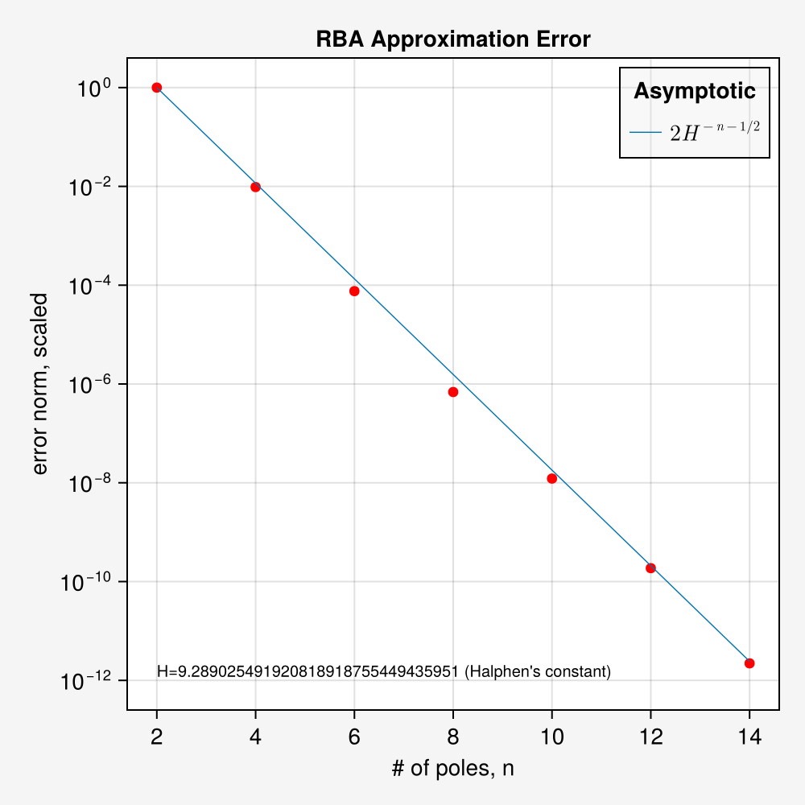

## Calculating the gradient

To get $\mathbf{u}'(\mathbf{m})$ for any fixed time $t$ we need to compute
$$\mathbf{u}'(\mathbf{m}) \leftarrow \sum_{k}\alpha_{k}
\left( [-t \mathbf{K} - \xi_{k}\mathbf{M}(\mathbf{m})]^{-1} \mathbf{f}\right)'$$
We denote
$$\mathbf{A}_{k}(\mathbf{m})^{-1} = \left[ -t \mathbf{K} - \xi_{k}\mathbf{M} \right] ^{-1} \quad \in \mathbb{C}^{N \times N}$$
Then the derivative is
$$(\mathbf{A}_{k}(\mathbf{m})^{-1})' = -\mathbf{A}_{k}^{-1} \mathbf{A}_{k}' \mathbf{A}_{k}^{-1}$$

## Calculating the gradient

Approximation to $\mathbf{u}'(\mathbf{m})$ from contributions of the form
$$\begin{align}
\frac{ \partial }{ \partial \mathbf{m} } \left[ \mathbf{A}_{k}(\mathbf{m})^{-1} \mathbf{f} \right] & = \alpha_{k}\xi_{k}\mathbf{A}_{k}^{-1} \mathbf{M}' \mathbf{A}^{-1} \mathbf{f} \\
& = \alpha_{k}\xi_{k}\mathbf{A}_{k}^{-1} \underbrace{ \left[ \widetilde{\mathbf{M}} \times_{2} \mathbf{A}_{k}^{-1}\mathbf{f} \right] }_{ N \times P } \underbrace{ \text{diag}[\exp(\mathbf{m})] }_{ P \times P} \quad \in \mathbb{C}^{N \times P}
\end{align}$$
with $\sigma_i = \exp(m_i)$ element-wise.

For CG we need to compute products with the *Jacobian* and its transpose
$$\left[\frac{ \partial }{ \partial \mathbf{m} } \mathbf{Q}\mathbf{u}\right]\mathbf{v} =: \mathbf{J}\mathbf{v} \text{ and } \mathbf{J}^\top \mathbf{w}$$

## Jacobian-times-vector products

The action of the $(M \times P)$ Jacobian on a $P$-vector $\mathbf{v}$ is

$$\mathbf{J}_{k}\mathbf{v} =
\alpha_{k}\xi_{k} \underbrace{ \mathbf{Q}\color{red}\mathbf{A}_{k}^{-1} }_{ M \times N } \underbrace{ \left[ \widetilde{\mathbf{M}} \times_{2} \color{blue}\mathbf{A}_{k}^{-1}\mathbf{f}\right] }_{ N \times P } \underbrace{ \text{diag}[\exp(\mathbf{m})]\mathbf{v} }_{ P } \quad \in\mathbb{R}^{M}$$
The product $\mathbf{J}^{(i)}\mathbf{v}$ for a single time $t_{i}$ is finally
$$\mathbf{J}^{(i)}\mathbf{v} = \sum_{k=1}^{m} \mathbf{J}^{(i)}_{k}\mathbf{v}$$

Numerical effort: For each $k$ and $t$ **one additional** forward solve with $\color {red}\mathbf{A}_k$, $\color{blue}\mathbf{A}_k^{-1}\mathbf{f}$ can be restored if stored in a cache. **Performance boost:** Compute (and possibly store) LU factorizations of $\color {blue}\mathbf{A}_k$ (at least) for current $t$.

For all times $t_i, i=1,2,\dots, K$ we form
$$\mathbf{J}\mathbf{v} =
\begin{bmatrix}
\mathbf{J}^{(1)} \\
\vdots \\
\mathbf{J}^{(K)} \\
\end{bmatrix} \mathbf{v} =
\begin{bmatrix}
\mathbf{J}^{(1)}\mathbf{v} \\
\vdots \\
\mathbf{J}^{(K)}\mathbf{v} \\
\end{bmatrix} \in \mathbb{R}^{KM}$$
and
$$\mathbf{J}^{\top}\mathbf{w} =
\begin{bmatrix}
\mathbf{J}^{\top (1)}
\,\cdots\,
\mathbf{J}^{\top (K)} \\
\end{bmatrix} \mathbf{w} =
\begin{bmatrix}
\mathbf{J}^{\top (1)}\mathbf{w}
\,\cdots\,
\mathbf{J}^{\top(K)}\mathbf{w} \\
\end{bmatrix} \in \mathbb{R}^{KP}$$

Given all that, we solve system of normal equations
$$\left( \mathbf{J}^{\top} \mathbf{J} + \lambda \mathbf{C}^{\top} \mathbf{C} \right) \mathbf{p}
= -\mathbf{J}^{\top} (\mathbf{Q}\mathbf{u} - \mathbf{d}) - \lambda \mathbf{C}^{\top} \mathbf{C} (\mathbf{m} - \mathbf{m}_\text{ref})$$
and obtain model update from a line search as $\mathbf{m}_{i+1} = \mathbf{m}_{i} + \alpha \mathbf{p}$.

## Numerical experiments

### Taylor test of Jacobian

We introduce the error norm functional
$$e(h) := \| \mathbf{u}(\mathbf{m} + h \Delta \mathbf{m}) - \mathbf{u}(\mathbf{m}) - h \underbrace{ \mathbf{u}'(\mathbf{m})\Delta \mathbf{m} }_{ =\mathbf{J}\mathbf{v} } \|_{2}$$
as a function of an appropriate step-length control variable $h$.

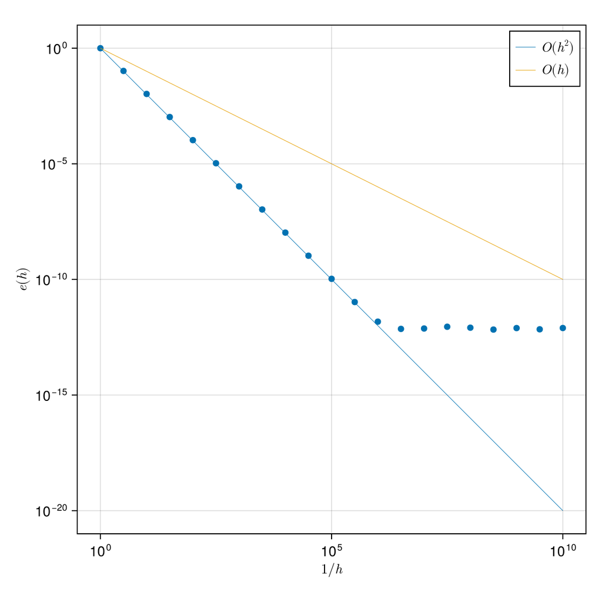

The error norm decays with $\mathcal O(h^{2})$ until break-down due to numerical inaccuracies.

## Numerical experiments

2-D/3-D Spatial discretization of the PDE from, e.g.:

- MATLAB library `FEMLAB` (Spitzer et al., 2023)
- Experimental `Julia` implementation, FE based on `Gridap.jl`
- 2-D toy problem with 8 points in space and 6 in time
- `Gridap.jl`
- Smoothness constraints using lowest order Raviart-Thomas elements
- Convergence after 6 GN iterations

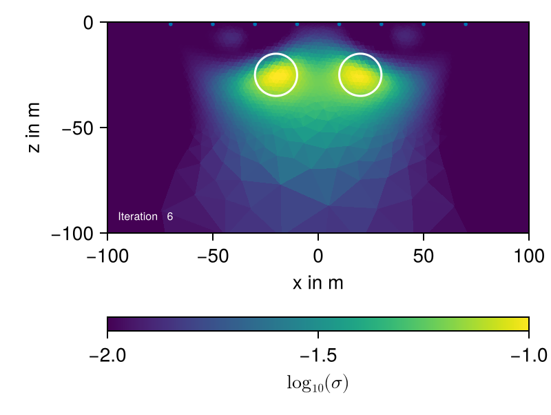

## Summary & Outlook

- RBA as time integrator for Maxwell’s equations
- Excellent approximation error
- Numerical effort: Requires system solves with $K \cdot m$ shifted systems
- Works with any discretization
- Well suited for, e.g., CG-based Gauss-Newton
- Deployment on HPC cluster
  - Caching of matrix factorizations
  - Large scale data inversion
- Open source `Julia` implementation